# Applying multiple linear regression to estimate VO2max

### Step 9. Leverage points.

Determine if there are any high leverage points that have the potential to influence the model.

```r
hats <- hatvalues(fit)
```

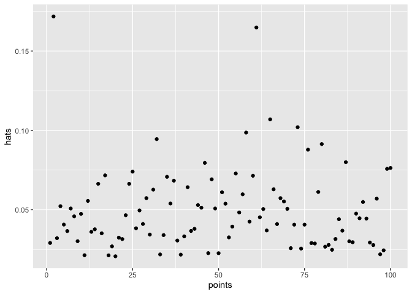

```r
ggplot(data = NULL, aes(x = points, y = hats)) +
  geom_point()
```

```r
# there are no hatvalues greater than 1, however we might investigate the points above 0.15
# as they seem to stick out above the rest
```

```r
hat_labels <- if_else(hats >= 0.15, paste(points), "")
```

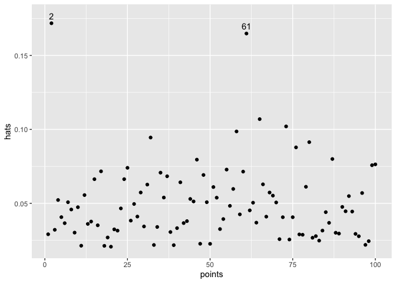

```r
ggplot(data = NULL, aes(x = points, y = hats)) +
  geom_point() +
  geom_text(aes(label = hat_labels), nudge_y = 0.005)
```

### Step 10. Influential points.

Determine if any of the points could be considered as points of high influence.

```r
cook <- cooks.distance(fit)
```

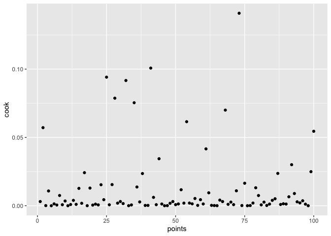

```r
ggplot(data = NULL, aes(x = points, y = cook)) +
  geom_point()
```

```r
# we might take a look at those points above 0.075 that are standing out above the rest
```

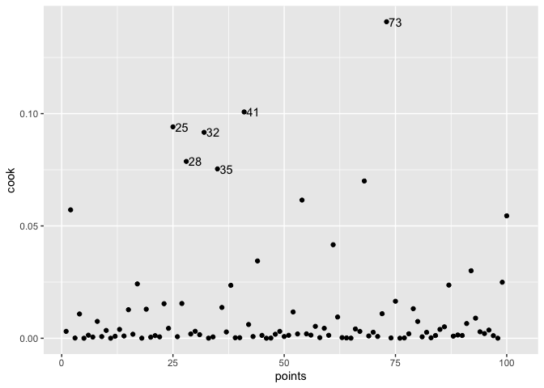

```r
cook_labels <- if_else(cook >= 0.075, paste(points), "")

ggplot(data = NULL, aes(x = points, y = cook)) +
  geom_point() +
  geom_text(aes(label = cook_labels), nudge_x = 2)
```

If you have determined there to be any points that are potentially high influence, remove these from the data and re-run your linear regression model.

Does doing so make much of a difference to the model? Don’t forget to check the R-Squared value using the `summary()` function as well as checking the intercept and slope coefficients.

If you find that these points do make a difference, what would be your next steps?

```r
# create new df without the high influence points

outliers <- c(25, 28, 32, 35, 41, 73) # store participant IDs to remove in object 'outliers'
filtered_df <- df %>%
  filter(!subject_id %in% outliers)  # filter if subject_id is not (!) %in% outliers
```

```r
# re-run the linear regression with filtered_df
fit2 <- lm(vo2_max ~ age + weight + heart_rate + gender, data = filtered_df)
tidy(fit2, conf.int = TRUE)
```

```
## # A tibble: 5 x 7
##   term        estimate std.error statistic  p.value conf.low conf.high
##   <chr>          <dbl>     <dbl>     <dbl>    <dbl>    <dbl>     <dbl>
## 1 (Intercept)  100.       5.13       19.5  7.01e-34   89.8    110.
## 2 age           -0.165    0.0495     -3.33 1.27e- 3   -0.263   -0.0665
## 3 weight        -0.504    0.0361    -14.0  4.00e-24   -0.576   -0.433
## 4 heart_rate    -0.148    0.0255     -5.82 9.27e- 8   -0.199   -0.0975
## 5 gender1       16.9      1.10       15.3  1.09e-26   14.7     19.1
```

```r
summary(fit2)
```

```
##
## Call:
## lm(formula = vo2_max ~ age + weight + heart_rate + gender, data = filtered_df)
##
## Residuals:
##      Min       1Q   Median       3Q      Max
## -13.1555  -1.7379  -0.1924   1.5306  17.0719
##
## Coefficients:
##              Estimate Std. Error t value Pr(>|t|)
## (Intercept) 100.00877    5.12941  19.497  < 2e-16 ***
## age          -0.16494    0.04954  -3.329  0.00127 **
## weight       -0.50438    0.03615 -13.953  < 2e-16 ***
## heart_rate   -0.14814    0.02547  -5.817 9.27e-08 ***
## gender1      16.86432    1.10069  15.322  < 2e-16 ***
## ---
## Signif. codes:  0 '***' 0.001 '**' 0.01 '*' 0.05 '.' 0.1 ' ' 1
##
## Residual standard error: 4.299 on 89 degrees of freedom
## Multiple R-squared:  0.7672, Adjusted R-squared:  0.7568
## F-statistic: 73.34 on 4 and 89 DF,  p-value: < 2.2e-16
```

```r
# removing these points has changed both the slope coefficient for weight, gender and the intercept coefficients quite a bit
# the R-squared value has improved by quite a lot, however we should be careful about removing outliers/influential data points that
# are real values as they can introduce bias into the model.
# we should check the outliers/influential data points to ensure that they are not due to measurement errors
# if they are not due to measurement errors we might consider transforming the variables and re-running the model, or choosing a different model type that is more robust to these points. Removing real data should be a last option
```